# BTC analytics R report: putting all together

Ivan Kashilov

December 13, 2019

Let’s have a look on Bitcoin stock price for the last year:

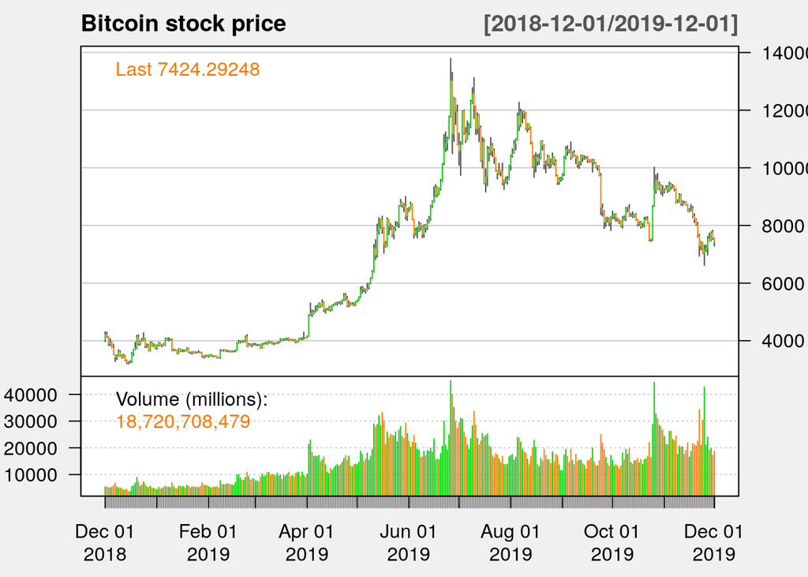

We scraped tweets with *#btc, #bitcoin, #cryptocurrency, #crypto, #finance, #news* hashtags  
for the same period. Now, let’s look how number of tweets distributed per day for the whole dataset:

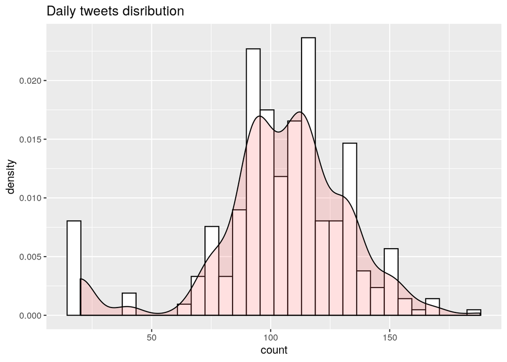

Now we can calculte average sentiment value per day and plot it. It will show us any correlation between people’s attitude to bitcoin and bitcoin stock price:

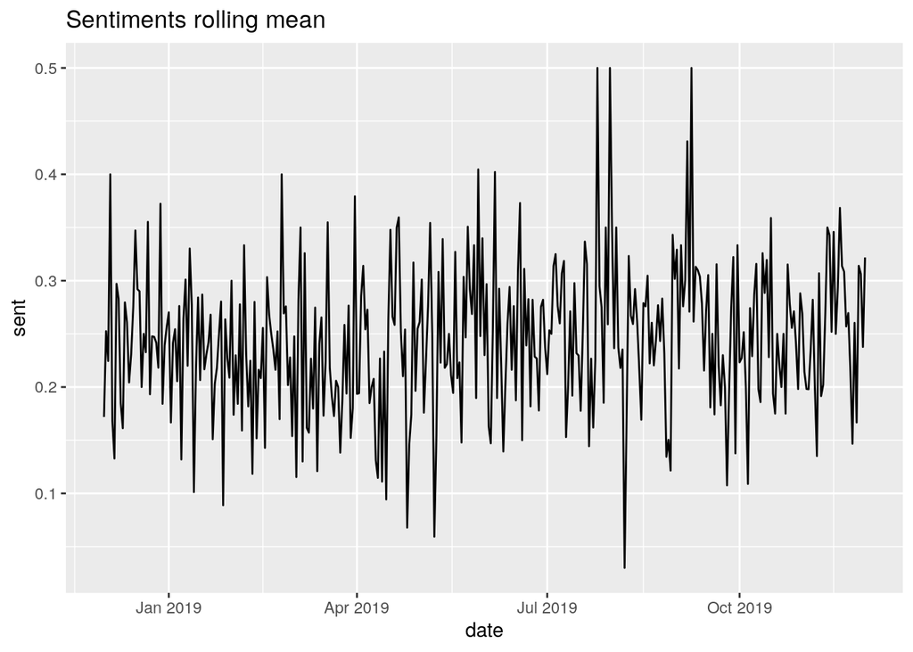

We can have a closer look at spikes on sentiments grapic and match them with relevant date range at stock price graphic:

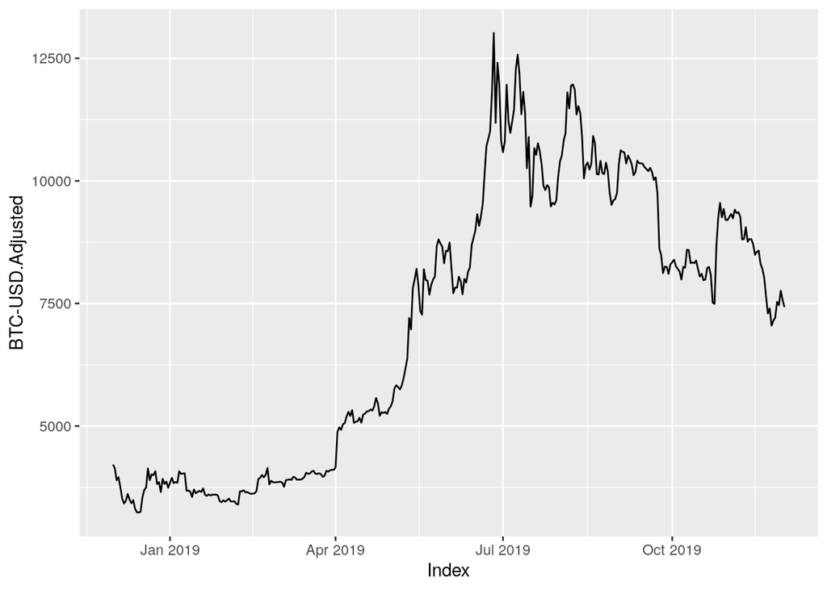

Now, using obtained average sentiments and stock price, let’s look on both at differnt angle: by plotting heatmaps:

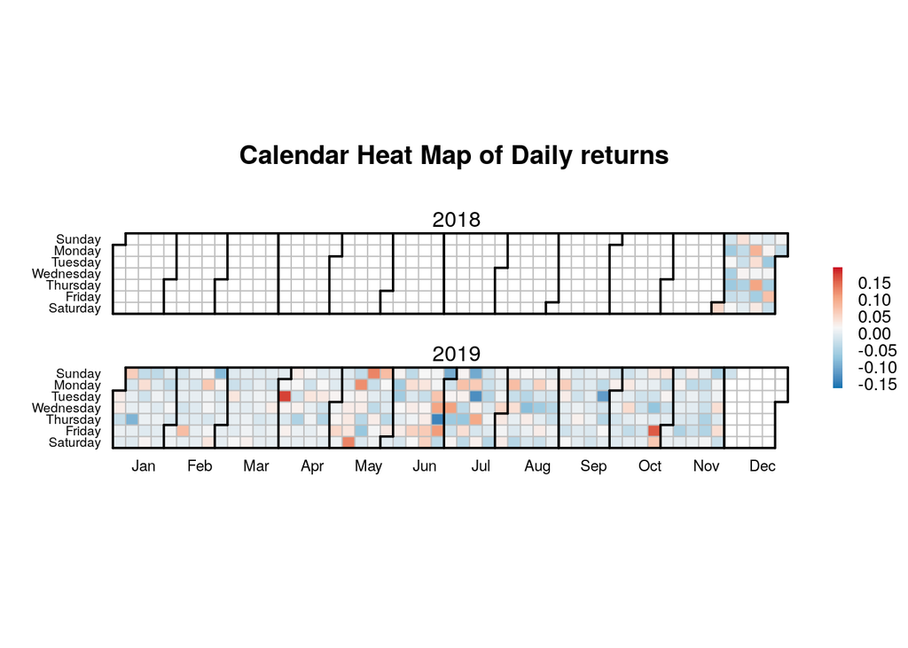

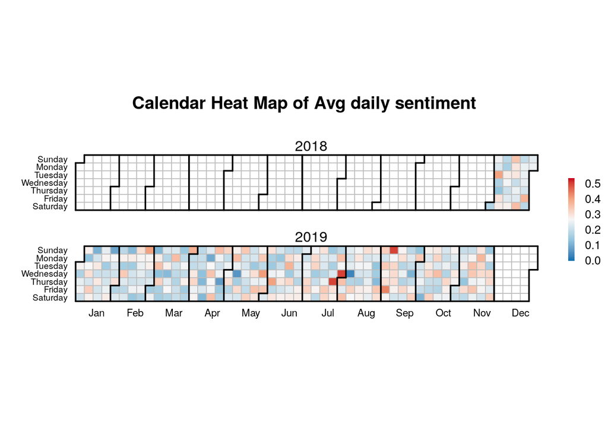

And finaly, let’s pick the most volatile period (mid June - mid August 2019) and analyse people’s sentimets deeper:

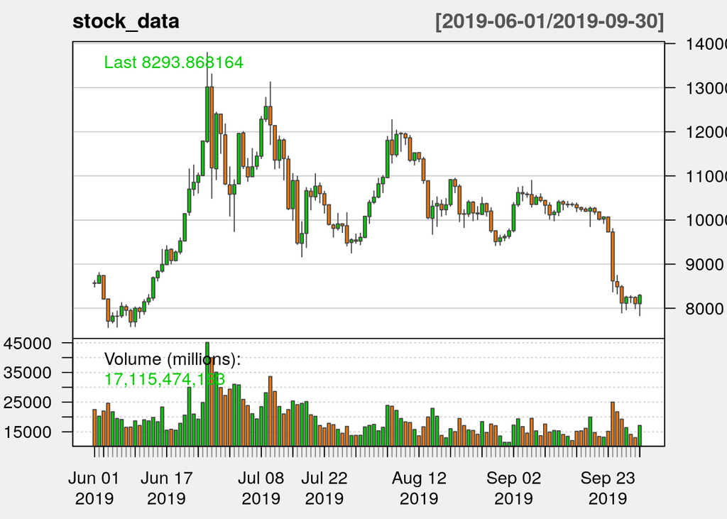

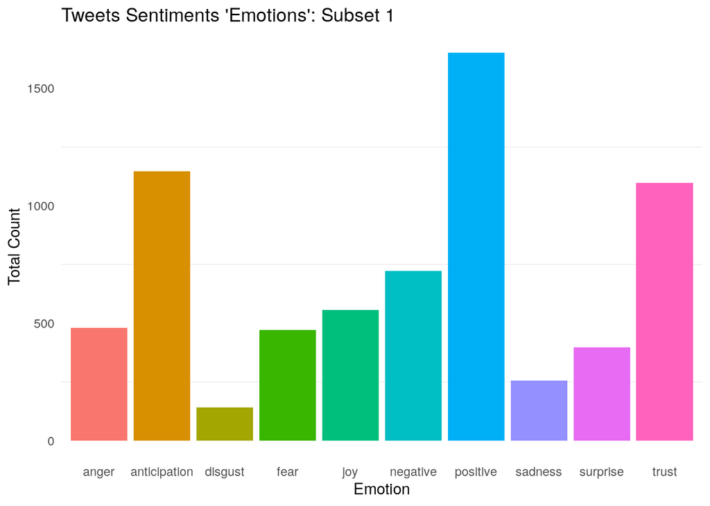

Range 2: mid July - mid August, when the price went down and then back up again:

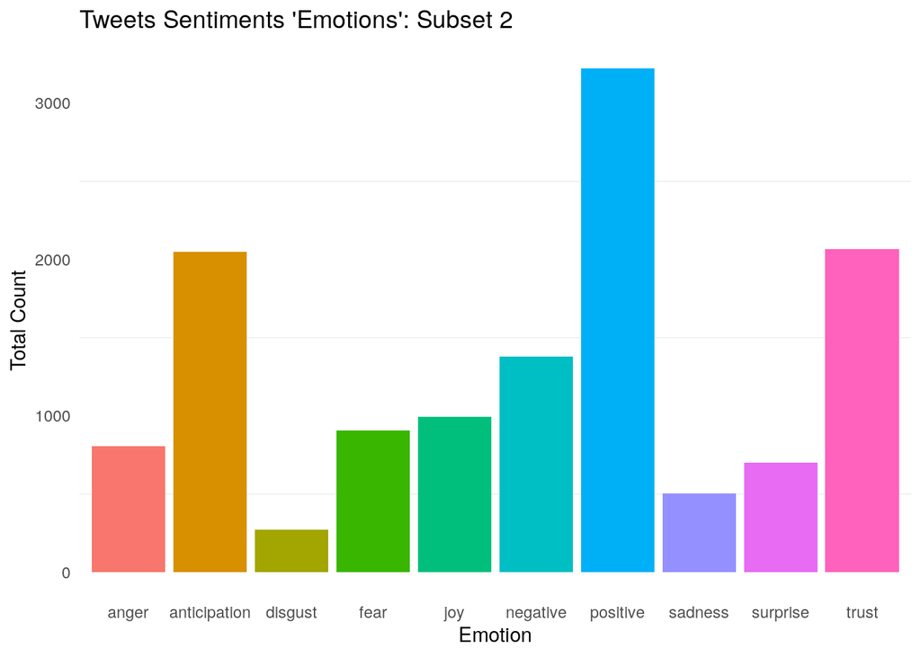

Range 3: mid August - Spetember 1st, when the price were falling down:

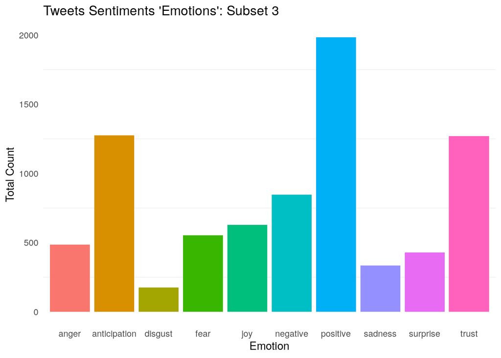

## Conclusion:

Unfortunately, juxtaposition of daily returns and daily sentiments does not show us any correlation. The last chapter (when we were looking at people’s emotions) shows as almost the same results due to simplicity of “emotions - extracting” approach. Also the data, scraped from twitter, was not filtered in any way. There were a lot of “unpopular” tweets (with number of likes less then 2). It can be quite possible, that hashtags did not refer to the content.  
So I find this pipeline very perspective despite the fact that the results so far cannot be interpreted in any way.